# W3cubDocs

## BatchNormTraining

See also [`ComputationBuilder::BatchNormTraining`](https://www.github.com/tensorflow/tensorflow/blob/r1.8/tensorflow/compiler/xla/client/computation_builder.h) and [`the original batch normalization paper`](https://arxiv.org/abs/1502.03167) for a detailed description of the algorithm.

Normalizes an array across batch and spatial dimensions.

**`BatchNormTraining(operand, scale, offset, epsilon, feature_index)`**

| Arguments | Type | Semantics |
| --- | --- | --- |
| `operand` | `ComputationDataHandle` | n dimensional array to be normalized (x) |
| `scale` | `ComputationDataHandle` | 1 dimensional array (\(\gamma\)) |
| `offset` | `ComputationDataHandle` | 1 dimensional array (\(\beta\)) |
| `epsilon` | `float` | Epsilon value (\(\epsilon\)) |
| `feature_index` | `int64` | Index to feature dimension in `operand` |

For each feature in the feature dimension (`feature_index` is the index for the feature dimension in `operand`), the operation calculates the mean and variance across all the other dimensions and uses the mean and variance to normalize each element in `operand`. The `feature_index` must be a valid index for the feature dimension in `operand`.

The algorithm goes as follows for each batch in `operand` \(x\) that contains `m` elements with `w` and `h` as the size of spatial dimensions (assuming `operand` is an 4 dimensional array):

- Calculates batch mean \(\mu_l\) for each feature `l` in feature dimension: \(\mu_l=\frac{1}{mwh}\sum_{i=1}^m\sum_{j=1}^w\sum_{k=1}^h x_{ijkl}\)
- Calculates batch variance \(\sigma^2_l\): \(\sigma^2_l=\frac{1}{mwh}\sum_{i=1}^m\sum_{j=1}^w\sum_{k=1}^h (x_{ijkl} - \mu_l)^2\)
- Normalizes, scales and shifts: \(y_{ijkl}=\frac{\gamma_l(x_{ijkl}-\mu_l)}{\sqrt[2]{\sigma^2_l+\epsilon}}+\beta_l\)

The epsilon value, usually a small number, is added to avoid divide-by-zero errors.

The output type is a tuple of three `ComputationDataHandle`s:

| Outputs | Type | Semantics |
| --- | --- | --- |
| `output` | `ComputationDataHandle` | n dimensional array with the same shape as input `operand` (y) |
| `batch_mean` | `ComputationDataHandle` | 1 dimensional array (\(\mu\)) |
| `batch_var` | `ComputationDataHandle` | 1 dimensional array (\(\sigma^2\)) |

The `batch_mean` and `batch_var` are moments calculated across the batch and spatial dimensions using the formulas above.

## BitcastConvertType

See also [`ComputationBuilder::BitcastConvertType`](https://www.github.com/tensorflow/tensorflow/blob/r1.8/tensorflow/compiler/xla/client/computation_builder.h).

Similar to a [`tf.bitcast`](https://www.tensorflow.org/api_docs/python/tf/bitcast) in TensorFlow, performs an element-wise bitcast operation from a data shape to a target shape. The dimensions must match, and the conversion is an element-wise one; e.g. `s32` elements become `f32` elements via bitcast routine. Bitcast is implemented as a low-level cast, so machines with different floating-point representations will give different results.

**`BitcastConvertType(operand, new_element_type)`**

| Arguments | Type | Semantics |
| --- | --- | --- |
| `operand` | `ComputationDataHandle` | array of type T with dims D |
| `new_element_type` | `PrimitiveType` | type U |

The dimensions of the operand and the target shape must match. The bit-width of the source and destination element types must be equal. The source and destination element types must not be tuples.

## Broadcast

See also [`ComputationBuilder::Broadcast`](https://www.github.com/tensorflow/tensorflow/blob/r1.8/tensorflow/compiler/xla/client/computation_builder.h).

Adds dimensions to an array by duplicating the data in the array.

**`Broadcast(operand, broadcast_sizes)`**

| Arguments | Type | Semantics |
| --- | --- | --- |
| `operand` | `ComputationDataHandle` | The array to duplicate |
| `broadcast_sizes` | `ArraySlice<int64>` | The sizes of the new dimensions |

The new dimensions are inserted on the left, i.e. if `broadcast_sizes` has values `{a0, ..., aN}` and the operand shape has dimensions `{b0, ..., bM}` then the shape of the output has dimensions `{a0, ..., aN, b0, ..., bM}`.

The new dimensions index into copies of the operand, i.e.

```
output[i0, ..., iN, j0, ..., jM] = operand[j0, ..., jM]
```

For example, if `operand` is a scalar `f32` with value `2.0f`, and `broadcast_sizes` is `{2, 3}`, then the result will be an array with shape `f32[2, 3]` and all the values in the result will be `2.0f`.

## Call

See also [`ComputationBuilder::Call`](https://www.github.com/tensorflow/tensorflow/blob/r1.8/tensorflow/compiler/xla/client/computation_builder.h).

Invokes a computation with the given arguments.

**`Call(computation, args...)`**

| Arguments | Type | Semantics |
| --- | --- | --- |
| `computation` | `Computation` | computation of type `T_0, T_1, ..., T_N -> S` with N parameters of arbitrary type |
| `args` | sequence of N `ComputationDataHandle`s | N arguments of arbitrary type |

The arity and types of the `args` must match the parameters of the `computation`. It is allowed to have no `args`.

## Clamp

See also [`ComputationBuilder::Clamp`](https://www.github.com/tensorflow/tensorflow/blob/r1.8/tensorflow/compiler/xla/client/computation_builder.h).

Clamps an operand to within the range between a minimum and maximum value.

**`Clamp(min, operand, max)`**

| Arguments | Type | Semantics |
| --- | --- | --- |
| `min` | `ComputationDataHandle` | array of type T |
| `operand` | `ComputationDataHandle` | array of type T |
| `max` | `ComputationDataHandle` | array of type T |

Given an operand and minimum and maximum values, returns the operand if it is in the range between the minimum and maximum, else returns the minimum value if the operand is below this range or the maximum value if the operand is above this range. That is, `clamp(a, x, b) = min(max(a, x), b)`.

All three arrays must be the same shape. Alternatively, as a restricted form of broadcasting, `min` and/or `max` can be a scalar of type `T`.

Example with scalar `min` and `max`:

```
let operand: s32[3] = {-1, 5, 9};
let min: s32 = 0;
let max: s32 = 6;
==>
Clamp(min, operand, max) = s32[3]{0, 5, 6};
```

## Collapse

See also [`ComputationBuilder::Collapse`](https://www.github.com/tensorflow/tensorflow/blob/r1.8/tensorflow/compiler/xla/client/computation_builder.h) and the [`tf.reshape`](https://www.tensorflow.org/api_docs/python/tf/reshape) operation.

Collapses dimensions of an array into one dimension.

**`Collapse(operand, dimensions)`**

| Arguments | Type | Semantics |
| --- | --- | --- |
| `operand` | `ComputationDataHandle` | array of type T |
| `dimensions` | `int64` vector | in-order, consecutive subset of T's dimensions. |

Collapse replaces the given subset of the operand's dimensions by a single dimension. The input arguments are an arbitrary array of type T and a compile-time-constant vector of dimension indices. The dimension indices must be an in-order (low to high dimension numbers), consecutive subset of T's dimensions. Thus, {0, 1, 2}, {0, 1}, or {1, 2} are all valid dimension sets, but {1, 0} or {0, 2} are not. They are replaced by a single new dimension, in the same position in the dimension sequence as those they replace, with the new dimension size equal to the product of original dimension sizes. The lowest dimension number in `dimensions` is the slowest varying dimension (most major) in the loop nest which collapses these dimension, and the highest dimension number is fastest varying (most minor). See the [`tf.reshape`](https://www.tensorflow.org/api_docs/python/tf/reshape) operator if more general collapse ordering is needed.

For example, let v be an array of 24 elements:

[output not shown]

## Concatenate

See also [`ComputationBuilder::ConcatInDim`](https://www.github.com/tensorflow/tensorflow/blob/r1.8/tensorflow/compiler/xla/client/computation_builder.h).

Concatenate composes an array from multiple array operands. The array is of the same rank as each of the input array operands (which must be of the same rank as each other) and contains the arguments in the order that they were specified.

**`Concatenate(operands..., dimension)`**

| Arguments | Type | Semantics |
| --- | --- | --- |
| `operands` | sequence of N `ComputationDataHandle` | N arrays of type T with dimensions [L0, L1, ...]. Requires N >= 1. |
| `dimension` | `int64` | A value in the interval `[0, N)` that names the dimension to be concatenated between the `operands`. |

With the exception of `dimension` all dimensions must be the same. This is because XLA does not support "ragged" arrays. Also note that rank-0 values cannot be concatenated (as it's impossible to name the dimension along which the concatenation occurs).

1-dimensional example:

```
Concat({ {2, 3}, {4, 5}, {6, 7}}, 0)
>>> {2, 3, 4, 5, 6, 7}
```

2-dimensional example:

```
let a = {
  {1, 2},
  {3, 4},
  {5, 6},
};
let b = {
  {7, 8},
};
Concat({a, b}, 0)
>>> {
  {1, 2},
  {3, 4},
  {5, 6},
  {7, 8},
}
```

Diagram:

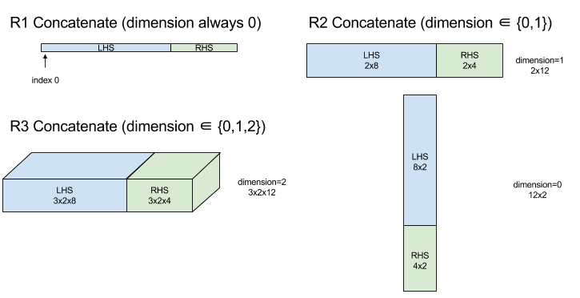

## Conditional

See also [`ComputationBuilder::Conditional`](https://www.github.com/tensorflow/tensorflow/blob/r1.8/tensorflow/compiler/xla/client/computation_builder.h).

**`Conditional(pred, true_operand, true_computation, false_operand, false_computation)`**

| Arguments | Type | Semantics |
| --- | --- | --- |
| `pred` | `ComputationDataHandle` | Scalar of type `PRED` |
| `true_operand` | `ComputationDataHandle` | Argument of type `T_0` |
| `true_computation` | `Computation` | Computation of type `T_0 -> S` |
| `false_operand` | `ComputationDataHandle` | Argument of type `T_1` |
| `false_computation` | `Computation` | Computation of type `T_1 -> S` |

Executes `true_computation` if `pred` is `true`, `false_computation` if `pred` is `false`, and returns the result.

The `true_computation` must take in a single argument of type `T_0` and will be invoked with `true_operand` which must be of the same type. The `false_computation` must take in a single argument of type `T_1` and will be invoked with `false_operand` which must be of the same type. The type of the returned value of `true_computation` and `false_computation` must be the same.

Note that only one of `true_computation` and `false_computation` will be executed depending on the value of `pred`.

## Conv (convolution)

See also [`ComputationBuilder::Conv`](https://www.github.com/tensorflow/tensorflow/blob/r1.8/tensorflow/compiler/xla/client/computation_builder.h).

As ConvWithGeneralPadding, but the padding is specified in a short-hand way as either SAME or VALID. SAME padding pads the input (`lhs`) with zeroes so that the output has the same shape as the input when not taking striding into account. VALID padding simply means no padding.

## ConvWithGeneralPadding (convolution)

See also [`ComputationBuilder::ConvWithGeneralPadding`](https://www.github.com/tensorflow/tensorflow/blob/r1.8/tensorflow/compiler/xla/client/computation_builder.h).

Computes a convolution of the kind used in neural networks. Here, a convolution can be thought of as a n-dimensional window moving across a n-dimensional base area and a computation is performed for each possible position of the window.

[output not shown]

Let n be the number of spatial dimensions. The `lhs` argument is a rank n+2 array describing the base area. This is called the input, even though of course the rhs is also an input. In a neural network, these are the input activations. The n+2 dimensions are, in this order:

- `batch`: Each coordinate in this dimension represents an independent input for which convolution is carried out.
- `z/depth/features`: Each (y,x) position in the base area has a vector associated to it, which goes into this dimension.
- `spatial_dims`: Describes the `n` spatial dimensions that define the base area that the window moves across.

The `rhs` argument is a rank n+2 array describing the convolutional filter/kernel/window. The dimensions are, in this order:

- `output-z`: The `z` dimension of the output.
- `input-z`: The size of this dimension should equal the size of the `z` dimension in lhs.
- `spatial_dims`: Describes the `n` spatial dimensions that define the n-d window that moves across the base area.

The `window_strides` argument specifies the stride of the convolutional window in the spatial dimensions. For example, if the stride in the first spatial dimension is 3, then the window can only be placed at coordinates where the first spatial index is divisible by 3.

The `padding` argument specifies the amount of zero padding to be applied to the base area. The amount of padding can be negative -- the absolute value of negative padding indicates the number of elements to remove from the specified dimension before doing the convolution. `padding[0]` specifies the padding for dimension `y` and `padding[1]` specifies the padding for dimension `x`. Each pair has the low padding as the first element and the high padding as the second element. The low padding is applied in the direction of lower indices while the high padding is applied in the direction of higher indices. For example, if `padding[1]` is `(2,3)` then there will be a padding by 2 zeroes on the left and by 3 zeroes on the right in the second spatial dimension. Using padding is equivalent to inserting those same zero values into the input (`lhs`) before doing the convolution.

The `lhs_dilation` and `rhs_dilation` arguments specify the dilation factor to be applied to the lhs and rhs, respectively, in each spatial dimension. If the dilation factor in a spatial dimension is d, then d-1 holes are implicitly placed between each of the entries in that dimension, increasing the size of the array. The holes are filled with a no-op value, which for convolution means zeroes.

Dilation of the rhs is also called atrous convolution. For more details, see [`tf.nn.atrous_conv2d`](https://www.tensorflow.org/api_docs/python/tf/nn/atrous_conv2d). Dilation of the lhs is also called transposed convolution. For more details, see [`tf.nn.conv2d_transpose`](https://www.tensorflow.org/api_docs/python/tf/nn/conv2d_transpose).

The output shape has these dimensions, in this order:

- `batch`: Same size as `batch` on the input (`lhs`).
- `z`: Same size as `output-z` on the kernel (`rhs`).
- `spatial_dims`: One value for each valid placement of the convolutional window.

The valid placements of the convolutional window are determined by the strides and the size of the base area after padding.

To describe what a convolution does, consider a 2d convolution, and pick some fixed `batch`, `z`, `y`, `x` coordinates in the output. Then `(y,x)` is a position of a corner of the window within the base area (e.g. the upper left corner, depending on how you interpret the spatial dimensions). We now have a 2d window, taken from the base area, where each 2d point is associated to a 1d vector, so we get a 3d box. From the convolutional kernel, since we fixed the output coordinate `z`, we also have a 3d box. The two boxes have the same dimensions, so we can take the sum of the element-wise products between the two boxes (similar to a dot product). That is the output value.

Note that if `output-z` is e.g., 5, then each position of the window produces 5 values in the output into the `z` dimension of the output. These values differ in what part of the convolutional kernel is used - there is a separate 3d box of values used for each `output-z` coordinate. So you could think of it as 5 separate convolutions with a different filter for each of them.

Here is pseudo-code for a 2d convolution with padding and striding:

```
for (b, oz, oy, ox) {  // output coordinates
  value = 0;
  for (iz, ky, kx) {  // kernel coordinates and input z
    iy = oy*stride_y + ky - pad_low_y;
    ix = ox*stride_x + kx - pad_low_x;
    if ((iy, ix) inside the base area considered without padding) {
      value += input(b, iz, iy, ix) * kernel(oz, iz, ky, kx);
    }
  }
  output(b, oz, oy, ox) = value;
}
```

## ConvertElementType

See also [`ComputationBuilder::ConvertElementType`](https://www.github.com/tensorflow/tensorflow/blob/r1.8/tensorflow/compiler/xla/client/computation_builder.h).

Similar to an element-wise `static_cast` in C++, performs an element-wise conversion operation from a data shape to a target shape. The dimensions must match, and the conversion is an element-wise one; e.g. `s32` elements become `f32` elements via an `s32`-to-`f32` conversion routine.

**`ConvertElementType(operand, new_element_type)`**

| Arguments | Type | Semantics |
| --- | --- | --- |
| `operand` | `ComputationDataHandle` | array of type T with dims D |
| `new_element_type` | `PrimitiveType` | type U |

The dimensions of the operand and the target shape must match. The source and destination element types must not be tuples.

A conversion such as `T=s32` to `U=f32` will perform a normalizing int-to-float conversion routine such as round-to-nearest-even.

> **Note:** The precise float-to-int and visa-versa conversions are currently unspecified, but may become additional arguments to the convert operation in the future. Not all possible conversions have been implemented for all targets.

```
let a: s32[3] = {0, 1, 2};
let b: f32[3] = convert(a, f32);
then b == f32[3]{0.0, 1.0, 2.0}
```

## CrossReplicaSum

See also [`ComputationBuilder::CrossReplicaSum`](https://www.github.com/tensorflow/tensorflow/blob/r1.8/tensorflow/compiler/xla/client/computation_builder.h).

Computes a sum across replicas.

**`CrossReplicaSum(operand)`**

| Arguments | Type | Semantics |
| --- | --- | --- |
| `operand` | `ComputationDataHandle` | Array to sum across replicas. |

The output shape is the same as the input shape. For example, if there are two replicas and the operand has the value `(1.0, 2.5)` and `(3.0, 5.25)` respectively on the two replicas, then the output value from this op will be `(4.0, 7.75)` on both replicas.

Computing the result of CrossReplicaSum requires having one input from each replica, so if one replica executes a CrossReplicaSum node more times than another, then the former replica will wait forever. Since the replicas are all running the same program, there are not a lot of ways for that to happen, but it is possible when a while loop's condition depends on data from infeed and the data that is infed causes the while loop to iterate more times on one replica than another.

## CustomCall

See also [`ComputationBuilder::CustomCall`](https://www.github.com/tensorflow/tensorflow/blob/r1.8/tensorflow/compiler/xla/client/computation_builder.h).

Call a user-provided function within a computation.

**`CustomCall(target_name, args..., shape)`**

| Arguments | Type | Semantics |
| --- | --- | --- |
| `target_name` | `string` | Name of the function. A call instruction will be emitted which targets this symbol name. |
| `args` | sequence of N `ComputationDataHandle`s | N arguments of arbitrary type, which will be passed to the function. |
| `shape` | `Shape` | Output shape of the function |

The function signature is the same, regardless of the arity or type of args:

```
extern "C" void target_name(void* out, void** in);
```

For example, if CustomCall is used as follows:

```
let x = f32[2] {1,2};
let y = f32[2x3] { {10, 20, 30}, {40, 50, 60}};

CustomCall("myfunc", {x, y}, f32[3x3])
```

Here is an example of an implementation of `myfunc`:

```
extern "C" void myfunc(void* out, void** in) {
  float (&x)[2] = *static_cast<float(*)[2]>(in[0]);
  float (&y)[2][3] = *static_cast<float(*)[2][3]>(in[1]);
  EXPECT_EQ(1, x[0]);
  EXPECT_EQ(2, x[1]);
  EXPECT_EQ(10, y[0][0]);
  EXPECT_EQ(20, y[0][1]);
  EXPECT_EQ(30, y[0][2]);
  EXPECT_EQ(40, y[1][0]);
  EXPECT_EQ(50, y[1][1]);
  EXPECT_EQ(60, y[1][2]);
  float (&z)[3][3] = *static_cast<float(*)[3][3]>(out);
  z[0][0] = x[1] + y[1][0];
  // ...
}
```

The user-provided function must not have side-effects and its execution must be idempotent.

> **Note:** The opaque nature of the user-provided function restricts optimization opportunities for the compiler. Try to express your computation in terms of native XLA ops whenever possible; only use CustomCall as a last resort.

## Dot

See also [`ComputationBuilder::Dot`](https://www.github.com/tensorflow/tensorflow/blob/r1.8/tensorflow/compiler/xla/client/computation_builder.h).

**`Dot(lhs, rhs)`**

| Arguments | Type | Semantics |
| --- | --- | --- |
| `lhs` | `ComputationDataHandle` | array of type T |
| `rhs` | `ComputationDataHandle` | array of type T |

The exact semantics of this operation depend on the ranks of the operands:

| Input | Output | Semantics |
| --- | --- | --- |
| vector [n] `dot` vector [n] | scalar | vector dot product |
| matrix [m x k] `dot` vector [k] | vector [m] | matrix-vector multiplication |
| matrix [m x k] `dot` matrix [k x n] | matrix [m x n] | matrix-matrix multiplication |

The operation performs sum of products over the last dimension of `lhs` and the one-before-last dimension of `rhs`. These are the "contracted" dimensions. The contracted dimensions of `lhs` and `rhs` must be of the same size. In practice, it can be used to perform dot products between vectors, vector/matrix multiplications or matrix/matrix multiplications.

## DotGeneral

See also [`ComputationBuilder::DotGeneral`](https://www.github.com/tensorflow/tensorflow/blob/r1.8/tensorflow/compiler/xla/client/computation_builder.h).

**`DotGeneral(lhs, rhs, dimension_numbers)`**

| Arguments | Type | Semantics |
| --- | --- | --- |
| `lhs` | `ComputationDataHandle` | array of type T |
| `rhs` | `ComputationDataHandle` | array of type T |
| `dimension_numbers` | `DotDimensionNumbers` | array of type T |

As Dot, but allows contracting and batch dimension numbers to be specified for both the 'lhs' and 'rhs'.

| DotDimensionNumbers Fields | Type | Semantics |
| --- | --- | --- |
| 'lhs_contracting_dimensions' | repeated int64 | 'lhs' contracting dimension numbers |
| 'rhs_contracting_dimensions' | repeated int64 | 'rhs' contracting dimension numbers |
| 'lhs_batch_dimensions' | repeated int64 | 'lhs' batch dimension numbers |
| 'rhs_batch_dimensions' | repeated int64 | 'rhs' batch dimension numbers |

DotGeneral performs the sum of products over contracting dimensions specified in 'dimension_numbers'.

Associated contracting dimension numbers from the 'lhs' and 'rhs' do not need to be the same, but must be listed in the same order in both 'lhs/rhs_contracting_dimensions' arrays and have the same dimension sizes. There must be exactly one contracting dimension on both 'lhs' and 'rhs'.

Example with contracting dimension numbers:

```
lhs = { {1.0, 2.0, 3.0},
        {4.0, 5.0, 6.0} }

rhs = { {1.0, 1.0, 1.0},
        {2.0, 2.0, 2.0} }

DotDimensionNumbers dnums;
dnums.add_lhs_contracting_dimensions(1);
dnums.add_rhs_contracting_dimensions(1);

DotGeneral(lhs, rhs, dnums) -> { {6.0, 12.0},
                                 {15.0, 30.0} }
```

Associated batch dimension numbers from the 'lhs' and 'rhs' must have the same dimension number, must be listed in the same order in both arrays, must have the same dimension sizes, and must be ordered before contracting and non-contracting/non-batch dimension numbers.

Example with batch dimension numbers (batch size 2, 2x2 matrices):

```
lhs = { { {1.0, 2.0},
          {3.0, 4.0} },
        { {5.0, 6.0},
          {7.0, 8.0} } }

rhs = { { {1.0, 0.0},
          {0.0, 1.0} },
        { {1.0, 0.0},
          {0.0, 1.0} } }

DotDimensionNumbers dnums;
dnums.add_lhs_contracting_dimensions(2);
dnums.add_rhs_contracting_dimensions(1);
dnums.add_lhs_batch_dimensions(0);
dnums.add_rhs_batch_dimensions(0);

DotGeneral(lhs, rhs, dnums) -> { { {1.0, 2.0},
                                   {3.0, 4.0} },
                                 { {5.0, 6.0},
                                   {7.0, 8.0} } }
```

| Input | Output | Semantics |
| --- | --- | --- |
| [b0, m, k] `dot` [b0, k, n] | [b0, m, n] | batch matmul |
| [b0, b1, m, k] `dot` [b0, b1, k, n] | [b0, b1, m, n] | batch matmul |

It follows that the resulting dimension number starts with the batch dimension, then the 'lhs' non-contracting/non-batch dimension, and finally the 'rhs' non-contracting/non-batch dimension.

## DynamicSlice

See also [`ComputationBuilder::DynamicSlice`](https://www.github.com/tensorflow/tensorflow/blob/r1.8/tensorflow/compiler/xla/client/computation_builder.h).

DynamicSlice extracts a sub-array from the input array at dynamic `start_indices`. The size of the slice in each dimension is passed in `size_indices`, which specify the end point of exclusive slice intervals in each dimension: [start, start + size). The shape of `start_indices` must be rank == 1, with dimension size equal to the rank of `operand`. Note: handling of out-of-bounds slice indices (generated by incorrect runtime calculation of 'start_indices') is currently implementation-defined.

**`DynamicSlice(operand, start_indices, size_indices)`**

[output not shown]

1-dimensional example:

```
let a = {0.0, 1.0, 2.0, 3.0, 4.0}
let s = {2}

DynamicSlice(a, s, {2}) produces:
  {2.0, 3.0}
```

2-dimensional example:

```
let b =
 { {0.0,  1.0,  2.0},
   {3.0,  4.0,  5.0},
   {6.0,  7.0,  8.0},
   {9.0, 10.0, 11.0} }
let s = {2, 1}

DynamicSlice(b, s, {2, 2}) produces:
  { { 7.0,  8.0},
    {10.0, 11.0} }
```

## DynamicUpdateSlice

See also [`ComputationBuilder::DynamicUpdateSlice`](https://www.github.com/tensorflow/tensorflow/blob/r1.8/tensorflow/compiler/xla/client/computation_builder.h).

DynamicUpdateSlice generates a result which is the value of the input array `operand`, with a slice `update` overwritten at `start_indices`. The shape of `update` determines the shape of the sub-array of the result which is updated. The shape of `start_indices` must be rank == 1, with dimension size equal to the rank of `operand`. Note: handling of out-of-bounds slice indices (generated by incorrect runtime calculation of 'start_indices') is currently implementation-defined.

**`DynamicUpdateSlice(operand, update, start_indices)`**

[output not shown]

1-dimensional example:

```
let a = {0.0, 1.0, 2.0, 3.0, 4.0}
let u = {5.0, 6.0}
let s = {2}

DynamicUpdateSlice(a, u, s) produces:
  {0.0, 1.0, 5.0, 6.0, 4.0}
```

2-dimensional example:

```
let b =
 { {0.0,  1.0,  2.0},
   {3.0,  4.0,  5.0},
   {6.0,  7.0,  8.0},
   {9.0, 10.0, 11.0} }
let u =
 { {12.0,  13.0},
   {14.0,  15.0},
   {16.0,  17.0} }

let s = {1, 1}

DynamicUpdateSlice(b, u, s) produces:
 { {0.0,  1.0,  2.0},
   {3.0, 12.0, 13.0},
   {6.0, 14.0, 15.0},
   {9.0, 16.0, 17.0} }
```

## Element-wise binary arithmetic operations

See also [`ComputationBuilder::Add`](https://www.github.com/tensorflow/tensorflow/blob/r1.8/tensorflow/compiler/xla/client/computation_builder.h).

A set of element-wise binary arithmetic operations is supported.

**`Op(lhs, rhs)`**

Where `Op` is one of `Add` (addition), `Sub` (subtraction), `Mul` (multiplication), `Div` (division), `Rem` (remainder), `Max` (maximum), `Min` (minimum), `LogicalAnd` (logical AND), or `LogicalOr` (logical OR).

| Arguments | Type | Semantics |
| --- | --- | --- |
| `lhs` | `ComputationDataHandle` | left-hand-side operand: array of type T |
| `rhs` | `ComputationDataHandle` | right-hand-side operand: array of type T |

The arguments' shapes have to be either similar or compatible. See the broadcasting documentation about what it means for shapes to be compatible. The result of an operation has a shape which is the result of broadcasting the two input arrays. In this variant, operations between arrays of different ranks are *not* supported, unless one of the operands is a scalar.

When `Op` is `Rem`, the sign of the result is taken from the dividend, and the absolute value of the result is always less than the divisor's absolute value.

An alternative variant with different-rank broadcasting support exists for these operations:

**`Op(lhs, rhs, broadcast_dimensions)`**

Where `Op` is the same as above. This variant of the operation should be used for arithmetic operations between arrays of different ranks (such as adding a matrix to a vector).

The additional `broadcast_dimensions` operand is a slice of integers used to expand the rank of the lower-rank operand up to the rank of the higher-rank operand. `broadcast_dimensions` maps the dimensions of the lower-rank shape to the dimensions of the higher-rank shape. The unmapped dimensions of the expanded shape are filled with dimensions of size one. Degenerate-dimension broadcasting then broadcasts the shapes along these degenerate dimensions to equalize the shapes of both operands. The semantics are described in detail on the broadcasting page.

## Element-wise comparison operations

See also [`ComputationBuilder::Eq`](https://www.github.com/tensorflow/tensorflow/blob/r1.8/tensorflow/compiler/xla/client/computation_builder.h).

A set of standard element-wise binary comparison operations is supported. Note that standard IEEE 754 floating-point comparison semantics apply when comparing floating-point types.

**`Op(lhs, rhs)`**

Where `Op` is one of `Eq` (equal-to), `Ne` (not equal-to), `Ge` (greater-or-equal-than), `Gt` (greater-than), `Le` (less-or-equal-than), `Lt` (less-than).

| Arguments | Type | Semantics |
| --- | --- | --- |
| `lhs` | `ComputationDataHandle` | left-hand-side operand: array of type T |
| `rhs` | `ComputationDataHandle` | right-hand-side operand: array of type T |

The arguments' shapes have to be either similar or compatible. See the broadcasting documentation about what it means for shapes to be compatible. The result of an operation has a shape which is the result of broadcasting the two input arrays with the element type `PRED`. In this variant, operations between arrays of different ranks are *not* supported, unless one of the operands is a scalar.

An alternative variant with different-rank broadcasting support exists for these operations:

**`Op(lhs, rhs, broadcast_dimensions)`**

Where `Op` is the same as above. This variant of the operation should be used for comparison operations between arrays of different ranks (such as adding a matrix to a vector).

The additional `broadcast_dimensions` operand is a slice of integers specifying the dimensions to use for broadcasting the operands. The semantics are described in detail on the broadcasting page.

## Element-wise unary functions

ComputationBuilder supports these element-wise unary functions:

**`Abs(operand)`** Element-wise abs `x -> |x|`.

**`Ceil(operand)`** Element-wise ceil `x -> ⌈x⌉`.

**`Cos(operand)`** Element-wise cosine `x -> cos(x)`.

**`Exp(operand)`** Element-wise natural exponential `x -> e^x`.

**`Floor(operand)`** Element-wise floor `x -> ⌊x⌋`.

**`IsFinite(operand)`** Tests whether each element of `operand` is finite, i.e., is not positive or negative infinity, and is not `NaN`. Returns an array of `PRED` values with the same shape as the input, where each element is `true` if and only if the corresponding input element is finite.

**`Log(operand)`** Element-wise natural logarithm `x -> ln(x)`.

**`LogicalNot(operand)`** Element-wise logical not `x -> !(x)`.

**`Neg(operand)`** Element-wise negation `x -> -x`.

**`Sign(operand)`** Element-wise sign operation `x -> sgn(x)` where

$$\text{sgn}(x) = \begin{cases} -1 & x < 0\\ 0 & x = 0\\ 1 & x > 0 \end{cases}$$

using the comparison operator of the element type of `operand`.

**`Tanh(operand)`** Element-wise hyperbolic tangent `x -> tanh(x)`.

| Arguments | Type | Semantics |
| --- | --- | --- |
| `operand` | `ComputationDataHandle` | The operand to the function |

The function is applied to each element in the `operand` array, resulting in an array with the same shape. It is allowed for `operand` to be a scalar (rank 0).

## Gather

The XLA gather operation stitches together several slices (each slice at a potentially different runtime offset) of an input tensor into an output tensor.

### General Semantics

See also [`ComputationBuilder::Gather`](https://www.github.com/tensorflow/tensorflow/blob/r1.8/tensorflow/compiler/xla/client/computation_builder.h). For a more intuitive description, see the "Informal Description" section below.

**`gather(operand, gather_indices, output_window_dims, elided_window_dims, window_bounds, gather_dims_to_operand_dims)`**

[output not shown]

For every index `Out` in the output tensor, we compute two things (more precisely described later):

- An index into `gather_indices.rank` - `1` dimensions of `gather_indices`, which gives us a starting index of a slice, *operand slice*, in the operand tensor. These `gather_indices.rank` - `1` dimensions are all the dimensions in `gather_indices` except `index_vector_dim`.
- A *window index* that has the same rank as the operand. This index is composed of the values in `Out` at dimensions `output_window_dims`, embedded with zeroes according to `elided_window_dims`.

The *window index* is the relative index of the element in *operand slice* that should be present in the output at index `Out`.

The output is a tensor of rank `output_window_dims.size` + `gather_indices.rank` - `1`. Additionally, as a shorthand, we define `output_gather_dims` of type `ArraySlice<int64>` as the set of dimensions in the output shape but not in `output_window_dims`, in ascending order. E.g. if the output tensor has rank `5`, `output_window_dims` is {`2`, `4`} then `output_gather_dims` is {`0`, `1`, `3`}

If `index_vector_dim` is equal to `gather_indices.rank` we implicitly consider `gather_indices` to have a trailing `1` dimension (i.e. if `gather_indices` was of shape `[6,7]` and `index_vector_dim` is `2` then we implicitly consider the shape of `gather_indices` to be `[6,7,1]`).

The bounds for the output tensor along dimension `i` is computed as follows:

1. If `i` is present in `output_gather_dims` (i.e. is equal to `output_gather_dims[k]` for some `k`) then we pick the corresponding dimension bounds out of `gather_indices.shape`, skipping `index_vector_dim` (i.e. pick `gather_indices.shape.dims`[`k`] if `k` < `index_vector_dim` and `gather_indices.shape.dims`[`k`+`1`] otherwise).
2. If `i` is present in `output_window_dims` (i.e. equal to `output_window_dims`[`k`] for some `k`) then we pick the corresponding bound out of `window_bounds` after accounting for `elided_window_dims` (i.e. we pick `adjusted_window_bounds`[`k`] where `adjusted_window_bounds` is `window_bounds` with the bounds at indices `elided_window_dims` removed).

The operand index `In` corresponding to an output index `Out` is computed as follows:

1. Let `G` = { `Out`[`k`] for `k` in `output_gather_dims` }. Use `G` to slice out vector `S` such that `S`[`i`] = `gather_indices`[Combine(`G`, `i`)] where Combine(A, b) inserts b at position `index_vector_dim` into A. Note that this is well defined even if `G` is empty -- if `G` is empty then `S` = `gather_indices`.
2. Create an index, `S`<sub>`in`</sub>, into `operand` using `S` by scattering `S` using the `gather_dims_to_operand_dims` map (`S`<sub>`in`</sub> is the starting indices for *operand slice* mentioned above). More precisely:
   1. `S`<sub>`in`</sub>[`gather_dims_to_operand_dims`[`k`]] = `S`[`k`] if `k` < `gather_dims_to_operand_dims.size`.
   2. `S`<sub>`in`</sub>[`_`] = `0` otherwise.
3. Create an index `W`<sub>`in`</sub> into `operand` by scattering the indices at the output window dimensions in `Out` according to the `elided_window_dims` set (`W`<sub>`in`</sub> is the *window index* mentioned above). More precisely:
   1. `W`<sub>`in`</sub>[`window_dims_to_operand_dims`(`k`)] = `Out`[`k`] if `k` < `output_window_dims.size` (`window_dims_to_operand_dims` is defined below).
   2. `W`<sub>`in`</sub>[`_`] = `0` otherwise.
4. `In` is `W`<sub>`in`</sub> + `S`<sub>`in`</sub> where + is element-wise addition.

`window_dims_to_operand_dims` is the monotonic function with domain [`0`, `output_window_dims.size`) and range [`0`, `operand.rank`) \ `elided_window_dims`. So if, e.g., `output_window_dims.size` is `4`, `operand.rank` is `6` and `elided_window_dims` is {`0`, `2`} then `window_dims_to_operand_dims` is {`0`→`1`, `1`→`3`, `2`→`4`, `3`→`5`}.

### Informal Description and Examples

`index_vector_dim` is set to `gather_indices.rank` - `1` in all of the examples that follow. More interesting values for `index_vector_dim` does not change the operation fundamentally, but makes the visual representation more cumbersome.

To get an intuition on how all of the above fits together, let's look at an example that gathers 5 slices of shape `[8,6]` from a `[16,11]` tensor. The position of a slice into the `[16,11]` tensor can be represented as an index vector of shape `S64[2]`, so the set of 5 positions can be represented as a `S64[5,2]` tensor.

The behavior of the gather operation can then be depicted as an index transformation that takes [`G`,`W`<sub>`0`</sub>,`W`<sub>`1`</sub>], an index in the output shape, and maps it to an element in the input tensor in the following way:

[figure not shown]

We first select an (`X`,`Y`) vector from the gather indices tensor using `G`. The element in the output tensor at index [`G`,`W`<sub>`0`</sub>,`W`<sub>`1`</sub>] is then the element in the input tensor at index [`X`+`W`<sub>`0`</sub>,`Y`+`W`<sub>`1`</sub>].

`window_bounds` is `[8,6]`, which decides the range of W<sub>`0`</sub> and W<sub>`1`</sub>, and this in turn decides the bounds of the slice.

This gather operation acts as a batch dynamic slice with `G` as the batch dimension.

The gather indices may be multidimensional. For instance, a more general version of the example above using a "gather indices" tensor of shape `[4,5,2]` would translate indices like this:

[figure not shown]

Again, this acts as a batch dynamic slice `G`<sub>`0`</sub> and `G`<sub>`1`</sub> as the batch dimensions. The window bounds are still `[8,6]`.

The gather operation in XLA generalizes the informal semantics outlined above in the following ways:

1. We can configure which dimensions in the output shape are the window dimensions (dimensions containing `W`<sub>`0`</sub>, `W`<sub>`1`</sub> in the last example). The output gather dimensions (dimensions containing `G`<sub>`0`</sub>, `G`<sub>`1`</sub> in the last example) are defined to be the output dimensions that are not window dimensions.
2. The number of output window dimensions explicitly present in the output shape may be smaller than the input rank. These "missing" dimensions, which are listed explicitly as `elided_window_dims`, must have a window bound of `1`. Since they have a window bound of `1` the only valid index for them is `0` and eliding them does not introduce ambiguity.
3. The slice extracted from the "Gather Indices" tensor ((`X`, `Y`) in the last example) may have fewer elements than the input tensor rank, and an explicit mapping dictates how the index should be expanded to have the same rank as the input.

As a final example, we use (2) and (3) to implement [`tf.gather_nd`](https://www.tensorflow.org/api_docs/python/tf/gather_nd):

[figure not shown]

`window_bounds` for this case is `[1,11]`. Intuitively this means that every index `X` in the gather indices tensor picks an entire row and the result is the concatenation of all these rows.

## GetTupleElement

See also [`ComputationBuilder::GetTupleElement`](https://www.github.com/tensorflow/tensorflow/blob/r1.8/tensorflow/compiler/xla/client/computation_builder.h).

Indexes into a tuple with a compile-time-constant value.

The value must be a compile-time-constant so that shape inference can determine the type of the resulting value.

This is analogous to `std::get<int N>(t)` in C++. Conceptually:

```
let v: f32[10] = f32[10]{0, 1, 2, 3, 4, 5, 6, 7, 8, 9};
let s: s32 = 5;
let t: (f32[10], s32) = tuple(v, s);
let element_1: s32 = gettupleelement(t, 1);  // Inferred shape matches s32.
```

See also [`tf.tuple`](https://www.tensorflow.org/api_docs/python/tf/tuple).

## Infeed

See also [`ComputationBuilder::Infeed`](https://www.github.com/tensorflow/tensorflow/blob/r1.8/tensorflow/compiler/xla/client/computation_builder.h).

**`Infeed(shape)`**

| Argument | Type | Semantics |
| --- | --- | --- |
| `shape` | `Shape` | Shape of the data read from the Infeed interface. The layout field of the shape must be set to match the layout of the data sent to the device; otherwise its behavior is undefined. |

Reads a single data item from the implicit Infeed streaming interface of the device, interpreting the data as the given shape and its layout, and returns a `ComputationDataHandle` of the data. Multiple Infeed operations are allowed in a computation, but there must be a total order among the Infeed operations. For example, two Infeeds in the code below have a total order since there is a dependency between the while loops.

```
result1 = while (condition, init = init_value) {
  Infeed(shape)
}

result2 = while (condition, init = result1) {
  Infeed(shape)
}
```

Nested tuple shapes are not supported. For an empty tuple shape, the Infeed operation is effectively a no-op and proceeds without reading any data from the Infeed of the device.

> **Note:** We plan to allow multiple Infeed operations without a total order, in which case the compiler will provide information about how the Infeed operations are serialized in the compiled program.

## Map

See also [`ComputationBuilder::Map`](https://www.github.com/tensorflow/tensorflow/blob/r1.8/tensorflow/compiler/xla/client/computation_builder.h).

**`Map(operands..., computation)`**

| Arguments | Type | Semantics |
| --- | --- | --- |
| `operands` | sequence of N `ComputationDataHandle`s | N arrays of types T_0..T_{N-1} |
| `computation` | `Computation` | computation of type `T_0, T_1, ..., T_{N + M -1} -> S` with N parameters of type T and M of arbitrary type |
| `dimensions` | `int64` array | array of map dimensions |
| `static_operands` | sequence of M `ComputationDataHandle`s | M arrays of arbitrary type |

Applies a scalar function over the given `operands` arrays, producing an array of the same dimensions where each element is the result of the mapped function applied to the corresponding elements in the input arrays with `static_operands` given as additional input to `computation`.

The mapped function is an arbitrary computation with the restriction that it has N inputs of scalar type `T` and a single output with type `S`. The output has the same dimensions as the operands except that the element type T is replaced with S.

For example: `Map(op1, op2, op3, computation, par1)` maps `elem_out <- computation(elem1, elem2, elem3, par1)` at each (multi-dimensional) index in the input arrays to produce the output array.

## Pad

See also [`ComputationBuilder::Pad`](https://www.github.com/tensorflow/tensorflow/blob/r1.8/tensorflow/compiler/xla/client/computation_builder.h).

**`Pad(operand, padding_value, padding_config)`**

| Arguments | Type | Semantics |
| --- | --- | --- |
| `operand` | `ComputationDataHandle` | array of type `T` |
| `padding_value` | `ComputationDataHandle` | scalar of type `T` to fill in the added padding |
| `padding_config` | `PaddingConfig` | padding amount on both edges (low, high) and between the elements of each dimension |

Expands the given `operand` array by padding around the array as well as between the elements of the array with the given `padding_value`. `padding_config` specifies the amount of edge padding and the interior padding for each dimension.

`PaddingConfig` is a repeated field of `PaddingConfigDimension`, which contains three fields for each dimension: `edge_padding_low`, `edge_padding_high`, and `interior_padding`. `edge_padding_low` and `edge_padding_high` specify the amount of padding added at the low-end (next to index 0) and the high-end (next to the highest index) of each dimension respectively. The amount of edge padding can be negative -- the absolute value of negative padding indicates the number of elements to remove from the specified dimension. `interior_padding` specifies the amount of padding added between any two elements in each dimension. Interior padding occurs logically before edge padding, so in the case of negative edge padding elements are removed from the interior-padded operand. This operation is a no-op if the edge padding pairs are all (0, 0) and the interior padding values are all 0. The figure below shows examples of different `edge_padding` and `interior_padding` values for a two-dimensional array.

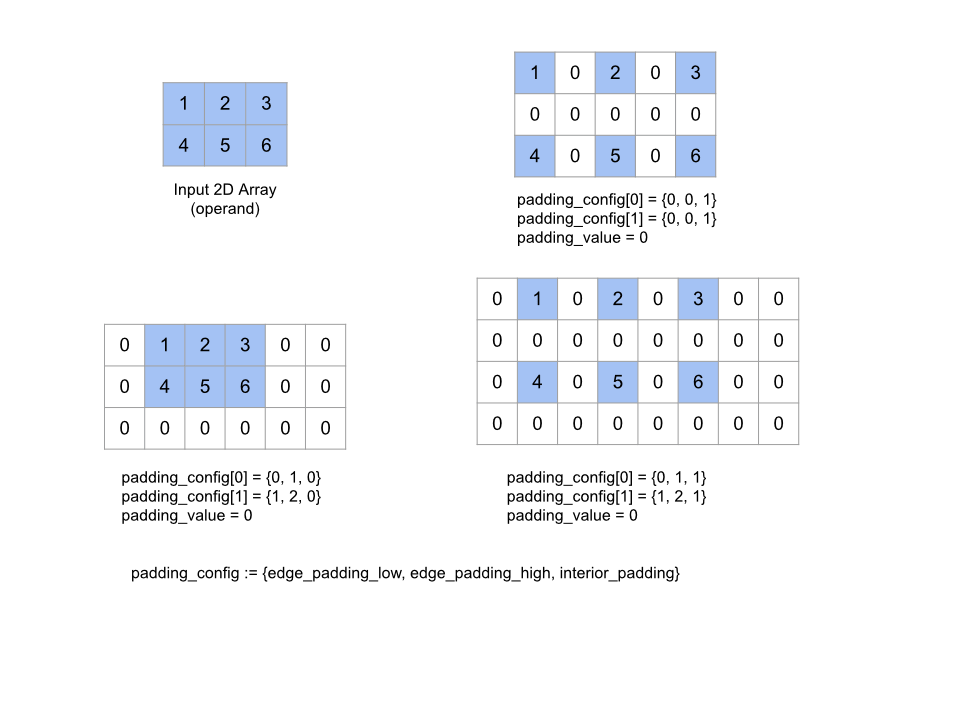

## Recv

See also [`ComputationBuilder::Recv`](https://www.github.com/tensorflow/tensorflow/blob/r1.8/tensorflow/compiler/xla/client/computation_builder.h).

**`Recv(shape, channel_handle)`**

| Arguments | Type | Semantics |
| --- | --- | --- |
| `shape` | `Shape` | shape of the data to receive |
| `channel_handle` | `ChannelHandle` | unique identifier for each send/recv pair |

Receives data of the given shape from a `Send` instruction in another computation that shares the same channel handle. Returns a ComputationDataHandle for the received data.

The client API of `Recv` operation represents synchronous communication. However, the instruction is internally decomposed into 2 HLO instructions (`Recv` and `RecvDone`) to enable asynchronous data transfers. See also [`HloInstruction::CreateRecv` and `HloInstruction::CreateRecvDone`](https://www.github.com/tensorflow/tensorflow/blob/r1.8/tensorflow/compiler/xla/service/hlo_instruction.h).

**`Recv(const Shape& shape, int64 channel_id)`**

Allocates resources required to receive data from a `Send` instruction with the same channel_id. Returns a context for the allocated resources, which is used by a following `RecvDone` instruction to wait for the completion of the data transfer. The context is a tuple of {receive buffer (shape), request identifier (U32)} and it can only be used by a `RecvDone` instruction.

**`RecvDone(HloInstruction context)`**

Given a context created by a `Recv` instruction, waits for the data transfer to complete and returns the received data.

## Reduce

See also [`ComputationBuilder::Reduce`](https://www.github.com/tensorflow/tensorflow/blob/r1.8/tensorflow/compiler/xla/client/computation_builder.h).

Applies a reduction function to an array.

**`Reduce(operand, init_value, computation, dimensions)`**

| Arguments | Type | Semantics |
| --- | --- | --- |
| `operand` | `ComputationDataHandle` | array of type `T` |
| `init_value` | `ComputationDataHandle` | scalar of type `T` |
| `computation` | `Computation` | computation of type `T, T -> T` |
| `dimensions` | `int64` array | unordered array of dimensions to reduce |

Conceptually, this operation reduces one or more dimensions in the input array into scalars. The rank of the result array is `rank(operand) - len(dimensions)`. `init_value` is the initial value used for every reduction and may also be inserted anywhere during computation if the back-end chooses to do so. So in most cases `init_value` should be an identity of the reduction function (for example, 0 for addition).

The evaluation order of the reduction function is arbitrary and may be non-deterministic. Therefore, the reduction function should not be overly sensitive to reassociation.

Some reduction functions like addition are not strictly associative for floats. However, if the range of the data is limited, floating-point addition is close enough to being associative for most practical uses. It is possible to conceive of some completely non-associative reductions, however, and these will produce incorrect or unpredictable results in XLA reductions.

As an example, when reducing across the one dimension in a 1D array with values [10, 11, 12, 13], with reduction function `f` (this is `computation`) then that could be computed as

`f(10, f(11, f(12, f(init_value, 13)))`

but there are also many other possibilities, e.g.

`f(init_value, f(f(10, f(init_value, 11)), f(f(init_value, 12), f(13, init_value))))`

The following is a rough pseudo-code example of how reduction could be implemented, using summation as the reduction computation with an initial value of 0.

```python
result_shape <- remove all dims in dimensions from operand_shape

# Iterate over all elements in result_shape. The number of r's here is equal
# to the rank of the result
for r0 in range(result_shape[0]), r1 in range(result_shape[1]), ...:
  # Initialize this result element
  result[r0, r1...] <- 0

  # Iterate over all the reduction dimensions
  for d0 in range(dimensions[0]), d1 in range(dimensions[1]), ...:
    # Increment the result element with the value of the operand's element.
    # The index of the operand's element is constructed from all ri's and di's
    # in the right order (by construction ri's and di's together index over the
    # whole operand shape).
    result[r0, r1...] += operand[ri... di]
```

Here's an example of reducing a 2D array (matrix). The shape has rank 2, dimension 0 of size 2 and dimension 1 of size 3:

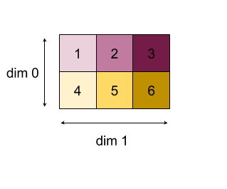

Results of reducing dimensions 0 or 1 with an "add" function:

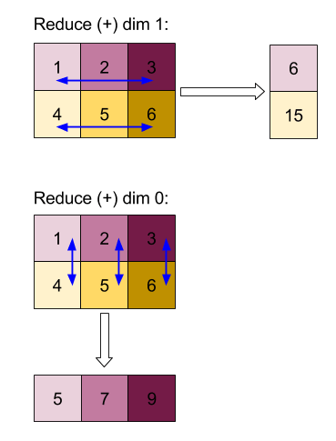

Note that both reduction results are 1D arrays. The diagram shows one as column and another as row just for visual convenience.

For a more complex example, here is a 3D array. Its rank is 3, dimension 0 of size 4, dimension 1 of size 2 and dimension 2 of size 3. For simplicity, the values 1 to 6 are replicated across dimension 0.

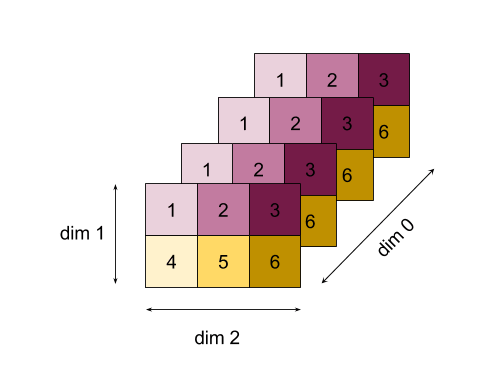

Similarly to the 2D example, we can reduce just one dimension. If we reduce dimension 0, for example, we get a rank-2 array where all values across dimension 0 were folded into a scalar:

```
|  4   8  12 |
| 16  20  24 |
```

If we reduce dimension 2, we also get a rank-2 array where all values across dimension 2 were folded into a scalar:

```
| 6  15 |
| 6  15 |
| 6  15 |
| 6  15 |
```

Note that the relative order between the remaining dimensions in the input is preserved in the output, but some dimensions may get assigned new numbers (since the rank changes).

We can also reduce multiple dimensions. Add-reducing dimensions 0 and 1 produces the 1D array `| 20 28 36 |`.

Reducing the 3D array over all its dimensions produces the scalar `84`.

## ReducePrecision

See also [`ComputationBuilder::ReducePrecision`](https://www.github.com/tensorflow/tensorflow/blob/r1.8/tensorflow/compiler/xla/client/computation_builder.h).

Models the effect of converting floating-point values to a lower-precision format (such as IEEE-FP16) and back to the original format. The number of exponent and mantissa bits in the lower-precision format can be specified arbitrarily, although all bit sizes may not be supported on all hardware implementations.

**`ReducePrecision(operand, mantissa_bits, exponent_bits)`**

| Arguments | Type | Semantics |
| --- | --- | --- |
| `operand` | `ComputationDataHandle` | array of floating-point type `T`. |
| `exponent_bits` | `int32` | number of exponent bits in lower-precision format |
| `mantissa_bits` | `int32` | number of mantissa bits in lower-precision format |

The result is an array of type `T`. The input values are rounded to the nearest value representable with the given number of mantissa bits (using "ties to even" semantics), and any values that exceed the range specified by the number of exponent bits are clamped to positive or negative infinity. `NaN` values are retained, although they may be converted to canonical `NaN` values.

The lower-precision format must have at least one exponent bit (in order to distinguish a zero value from an infinity, since both have a zero mantissa), and must have a non-negative number of mantissa bits. The number of exponent or mantissa bits may exceed the corresponding value for type `T`; the corresponding portion of the conversion is then simply a no-op.

## ReduceWindow

See also [`ComputationBuilder::ReduceWindow`](https://www.github.com/tensorflow/tensorflow/blob/r1.8/tensorflow/compiler/xla/client/computation_builder.h).

Applies a reduction function to all elements in each window of the input multi-dimensional array, producing an output multi-dimensional array with the same number of elements as the number of valid positions of the window. A pooling layer can be expressed as a `ReduceWindow`.

**`ReduceWindow(operand, init_value, computation, window_dimensions, window_strides, padding)`**

| Arguments | Type | Semantics |
| --- | --- | --- |
| `operand` | `ComputationDataHandle` | N dimensional array containing elements of type T. This is the base area on which the window is placed. |
| `init_value` | `ComputationDataHandle` | Starting value for the reduction. See Reduce for details. |
| `computation` | `Computation` | Reduction function of type `T, T -> T`, to apply to all elements in each window |
| `window_dimensions` | `ArraySlice<int64>` | array of integers for window dimension values |
| `window_strides` | `ArraySlice<int64>` | array of integers for window stride values |
| `padding` | `Padding` | padding type for window (Padding\:\:kSame or Padding\:\:kValid) |

Below code and figure shows an example of using `ReduceWindow`. Input is a matrix of size [4x6] and both window_dimensions and window_stride_dimensions are [2x3].

```
// Create a computation for the reduction (maximum).
Computation max;
{
  ComputationBuilder builder(client_, "max");
  auto y = builder.Parameter(0, ShapeUtil::MakeShape(F32, {}), "y");
  auto x = builder.Parameter(1, ShapeUtil::MakeShape(F32, {}), "x");
  builder.Max(y, x);
  max = builder.Build().ConsumeValueOrDie();
}

// Create a ReduceWindow computation with the max reduction computation.
ComputationBuilder builder(client_, "reduce_window_2x3");
auto shape = ShapeUtil::MakeShape(F32, {4, 6});
auto input = builder.Parameter(0, shape, "input");
builder.ReduceWindow(
    input, *max,
    /*init_val=*/builder.ConstantLiteral(LiteralUtil::MinValue(F32)),
    /*window_dimensions=*/{2, 3},
    /*window_stride_dimensions=*/{2, 3},
    Padding::kValid);
```

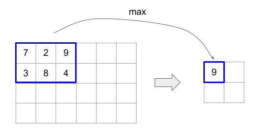

Stride of 1 in a dimension specifies that the position of a window in the dimension is 1 element away from its adjacent window. In order to specify that no windows overlap with each other, window_stride_dimensions should be equal to window_dimensions. The figure below illustrates the use of two different stride values. Padding is applied to each dimension of the input and the calculations are the same as though the input came in with the dimensions it has after padding.

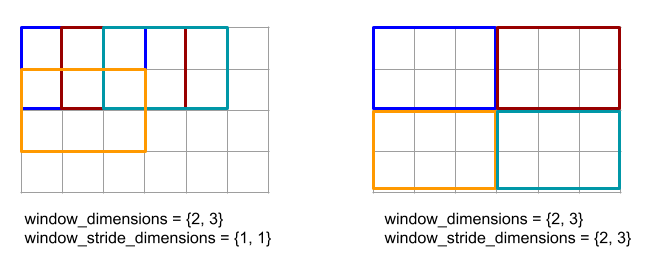

The evaluation order of the reduction function is arbitrary and may be non-deterministic. Therefore, the reduction function should not be overly sensitive to reassociation. See the discussion about associativity in the context of `Reduce` for more details.

## Reshape

See also [`ComputationBuilder::Reshape`](https://www.github.com/tensorflow/tensorflow/blob/r1.8/tensorflow/compiler/xla/client/computation_builder.h) and the `Collapse` operation.

Reshapes the dimensions of an array into a new configuration.

**`Reshape(operand, new_sizes)`** **`Reshape(operand, dimensions, new_sizes)`**

| Arguments | Type | Semantics |
| --- | --- | --- |
| `operand` | `ComputationDataHandle` | array of type T |
| `dimensions` | `int64` vector | order in which dimensions are collapsed |
| `new_sizes` | `int64` vector | vector of sizes of new dimensions |

Conceptually, reshape first flattens an array into a one-dimensional vector of data values, and then refines this vector into a new shape. The input arguments are an arbitrary array of type T, a compile-time-constant vector of dimension indices, and a compile-time-constant vector of dimension sizes for the result. The values in the `dimension` vector, if given, must be a permutation of all of T's dimensions; the default if not given is `{0, ..., rank - 1}`. The order of the dimensions in `dimensions` is from slowest-varying dimension (most major) to fastest-varying dimension (most minor) in the loop nest which collapses the input array into a single dimension. The `new_sizes` vector determines the size of the output array. The value at index 0 in `new_sizes` is the size of dimension 0, the value at index 1 is the size of dimension 1, and so on. The product of the `new_size` dimensions must equal the product of the operand's dimension sizes. When refining the collapsed array into the multidimensional array defined by `new_sizes`, the dimensions in `new_sizes` are ordered from slowest varying (most major) and to fastest varying (most minor).

For example, let v be an array of 24 elements:

```
let v = f32[4x2x3] { { {10, 11, 12}, {15, 16, 17}},
                    { {20, 21, 22}, {25, 26, 27}},
                    { {30, 31, 32}, {35, 36, 37}},
                    { {40, 41, 42}, {45, 46, 47}}};

In-order collapse:
let v012_24 = Reshape(v, {0,1,2}, {24});
then v012_24 == f32[24] {10, 11, 12, 15, 16, 17, 20, 21, 22, 25, 26, 27,
                         30, 31, 32, 35, 36, 37, 40, 41, 42, 45, 46, 47};

let v012_83 = Reshape(v, {0,1,2}, {8,3});
then v012_83 == f32[8x3] { {10, 11, 12}, {15, 16, 17},
                          {20, 21, 22}, {25, 26, 27},
                          {30, 31, 32}, {35, 36, 37},
                          {40, 41, 42}, {45, 46, 47}};

Out-of-order collapse:
let v021_24 = Reshape(v, {1,2,0}, {24});
then v012_24 == f32[24]  {10, 20, 30, 40, 11, 21, 31, 41, 12, 22, 32, 42,
                          15, 25, 35, 45, 16, 26, 36, 46, 17, 27, 37, 47};

let v021_83 = Reshape(v, {1,2,0}, {8,3});
then v021_83 == f32[8x3] { {10, 20, 30}, {40, 11, 21},
                          {31, 41, 12}, {22, 32, 42},
                          {15, 25, 35}, {45, 16, 26},
                          {36, 46, 17}, {27, 37, 47}};

let v021_262 = Reshape(v, {1,2,0}, {2,6,2});
then v021_262 == f32[2x6x2] { { {10, 20}, {30, 40},
                              {11, 21}, {31, 41},
                              {12, 22}, {32, 42}},
                             { {15, 25}, {35, 45},
                              {16, 26}, {36, 46},
                              {17, 27}, {37, 47}}};
```

As a special case, reshape can transform a single-element array to a scalar and vice versa. For example,

```
Reshape(f32[1x1] { {5}}, {0,1}, {}) == 5;
Reshape(5, {}, {1,1}) == f32[1x1] { {5}};
```

## Rev (reverse)

See also [`ComputationBuilder::Rev`](https://www.github.com/tensorflow/tensorflow/blob/r1.8/tensorflow/compiler/xla/client/computation_builder.h).

**`Rev(operand, dimensions)`**

| Arguments | Type | Semantics |
| --- | --- | --- |
| `operand` | `ComputationDataHandle` | array of type T |
| `dimensions` | `ArraySlice<int64>` | dimensions to reverse |

Reverses the order of elements in the `operand` array along the specified `dimensions`, generating an output array of the same shape. Each element of the operand array at a multidimensional index is stored into the output array at a transformed index. The multidimensional index is transformed by reversing the index in each dimension to be reversed (i.e., if a dimension of size N is one of the reversing dimensions, its index i is transformed into N - 1 - i).

One use for the `Rev` operation is to reverse the convolution weight array along the two window dimensions during the gradient computation in neural networks.

## RngNormal

See also [`ComputationBuilder::RngNormal`](https://www.github.com/tensorflow/tensorflow/blob/r1.8/tensorflow/compiler/xla/client/computation_builder.h).

output shape have to have elemental type F32. The parameters furthermore have to be scalar valued.

**`RngNormal(mean, sigma, shape)`**

| Arguments | Type | Semantics |
| --- | --- | --- |
| `mu` | `ComputationDataHandle` | Scalar of type F32 specifying mean of generated numbers |
| `sigma` | `ComputationDataHandle` | Scalar of type F32 specifying standard deviation of generated numbers |
| `shape` | `Shape` | Output shape of type F32 |

## RngUniform

See also [`ComputationBuilder::RngUniform`](https://www.github.com/tensorflow/tensorflow/blob/r1.8/tensorflow/compiler/xla/client/computation_builder.h).

shape may be either F32, S32 or U32, but the types have to be consistent.

is implementation-defined.

**`RngUniform(a, b, shape)`**

| Arguments | Type | Semantics |
| --- | --- | --- |
| `a` | `ComputationDataHandle` | Scalar of type T specifying lower limit of interval |
| `b` | `ComputationDataHandle` | Scalar of type T specifying upper limit of interval |
| `shape` | `Shape` | Output shape of type T |

## Select

See also [`ComputationBuilder::Select`](https://www.github.com/tensorflow/tensorflow/blob/r1.8/tensorflow/compiler/xla/client/computation_builder.h).

Constructs an output array from elements of two input arrays, based on the values of a predicate array.

**`Select(pred, on_true, on_false)`**

| Arguments | Type | Semantics |
| --- | --- | --- |
| `pred` | `ComputationDataHandle` | array of type PRED |
| `on_true` | `ComputationDataHandle` | array of type T |
| `on_false` | `ComputationDataHandle` | array of type T |

The arrays `on_true` and `on_false` must have the same shape. This is also the shape of the output array. The array `pred` must have the same dimensionality as `on_true` and `on_false`, with the `PRED` element type.

For each element `P` of `pred`, the corresponding element of the output array is taken from `on_true` if the value of `P` is `true`, and from `on_false` if the value of `P` is `false`. As a restricted form of broadcasting , `pred` can be a scalar of type `PRED`. In this case, the output array is taken wholly from `on_true` if `pred` is `true`, and from `on_false` if `pred` is `false`.

Example with non-scalar `pred`:

```
let pred: PRED[4] = {true, false, false, true};
let v1: s32[4] = {1, 2, 3, 4};
let v2: s32[4] = {100, 200, 300, 400};
==>
Select(pred, v1, v2) = s32[4]{1, 200, 300, 4};
```

Example with scalar `pred`:

```
let pred: PRED = true;
let v1: s32[4] = {1, 2, 3, 4};
let v2: s32[4] = {100, 200, 300, 400};
==>
Select(pred, v1, v2) = s32[4]{1, 2, 3, 4};
```

Selections between tuples are supported. Tuples are considered to be scalar types for this purpose. If `on_true` and `on_false` are tuples (which must have the same shape!) then `pred` has to be a scalar of type `PRED`.

## SelectAndScatter

See also [`ComputationBuilder::SelectAndScatter`](https://www.github.com/tensorflow/tensorflow/blob/r1.8/tensorflow/compiler/xla/client/computation_builder.h).

This operation can be considered as a composite operation that first computes `ReduceWindow` on the `operand` array to select an element from each window, and then scatters the `source` array to the indices of the selected elements to construct an output array with the same shape as the operand array. The binary `select` function is used to select an element from each window by applying it across each window, and it is called with the property that the first parameter's index vector is lexicographically less than the second parameter's index vector. The `select` function returns `true` if the first parameter is selected and returns `false` if the second parameter is selected, and the function must hold transitivity (i.e., if `select(a, b)` and `select(b, c)` are `true`, then `select(a, c)` is also `true`) so that the selected element does not depend on the order of the elements traversed for a given window.

The function `scatter` is applied at each selected index in the output array. It takes two scalar parameters:

1. Current value at the selected index in the output array
2. The scatter value from `source` that applies to the selected index

It combines the two parameters and returns a scalar value that's used to update the value at the selected index in the output array. Initially, all indices of the output array are set to `init_value`.

The output array has the same shape as the `operand` array and the `source` array must have the same shape as the result of applying a `ReduceWindow` operation on the `operand` array. `SelectAndScatter` can be used to backpropagate the gradient values for a pooling layer in a neural network.

**`SelectAndScatter(operand, select, window_dimensions, window_strides, padding, source, init_value, scatter)`**

| Arguments | Type | Semantics |
| --- | --- | --- |
| `operand` | `ComputationDataHandle` | array of type T over which the windows slide |
| `select` | `Computation` | binary computation of type `T, T -> PRED`, to apply to all elements in each window; returns `true` if the first parameter is selected and returns `false` if the second parameter is selected |
| `window_dimensions` | `ArraySlice<int64>` | array of integers for window dimension values |
| `window_strides` | `ArraySlice<int64>` | array of integers for window stride values |
| `padding` | `Padding` | padding type for window (Padding\:\:kSame or Padding\:\:kValid) |
| `source` | `ComputationDataHandle` | array of type T with the values to scatter |
| `init_value` | `ComputationDataHandle` | scalar value of type T for the initial value of the output array |
| `scatter` | `Computation` | binary computation of type `T, T -> T`, to apply each scatter source element with its destination element |

The figure below shows examples of using `SelectAndScatter`, with the `select` function computing the maximal value among its parameters. Note that when the windows overlap, as in the figure (2) below, an index of the `operand` array may be selected multiple times by different windows. In the figure, the element of value 9 is selected by both of the top windows (blue and red) and the binary addition `scatter` function produces the output element of value 8 (2 + 6).

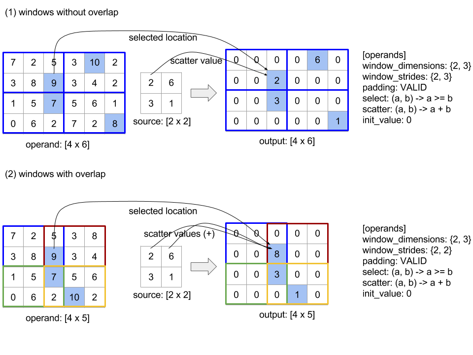

The evaluation order of the `scatter` function is arbitrary and may be non-deterministic. Therefore, the `scatter` function should not be overly sensitive to reassociation. See the discussion about associativity in the context of `Reduce` for more details.

## Send

See also [`ComputationBuilder::Send`](https://www.github.com/tensorflow/tensorflow/blob/r1.8/tensorflow/compiler/xla/client/computation_builder.h).

**`Send(operand, channel_handle)`**

| Arguments | Type | Semantics |
| --- | --- | --- |
| `operand` | `ComputationDataHandle` | data to send (array of type T) |
| `channel_handle` | `ChannelHandle` | unique identifier for each send/recv pair |

Sends the given operand data to a `Recv` instruction in another computation that shares the same channel handle. Does not return any data.

Similar to the `Recv` operation, the client API of `Send` operation represents synchronous communication, and is internally decomposed into 2 HLO instructions (`Send` and `SendDone`) to enable asynchronous data transfers. See also [`HloInstruction::CreateSend` and `HloInstruction::CreateSendDone`](https://www.github.com/tensorflow/tensorflow/blob/r1.8/tensorflow/compiler/xla/service/hlo_instruction.h).

**`Send(HloInstruction operand, int64 channel_id)`**

Initiates an asynchronous transfer of the operand to the resources allocated by the `Recv` instruction with the same channel id. Returns a context, which is used by a following `SendDone` instruction to wait for the completion of the data transfer. The context is a tuple of {operand (shape), request identifier (U32)} and it can only be used by a `SendDone` instruction.

**`SendDone(HloInstruction context)`**

Given a context created by a `Send` instruction, waits for the data transfer to complete. The instruction does not return any data.

**Scheduling of channel instructions**

The execution order of the 4 instructions for each channel (`Recv`, `RecvDone`, `Send`, `SendDone`) is as below.

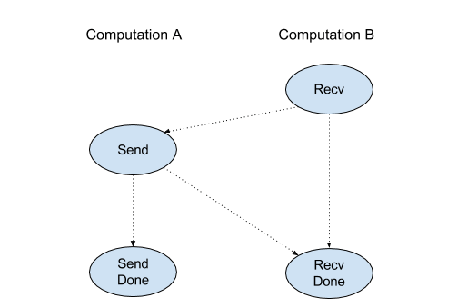

- `Recv` happens before `Send`
- `Send` happens before `RecvDone`
- `Recv` happens before `RecvDone`
- `Send` happens before `SendDone`

When the backend compilers generate a linear schedule for each computation that communicates via channel instructions, there must not be cycles across the computations. For example, below schedules lead to deadlocks.

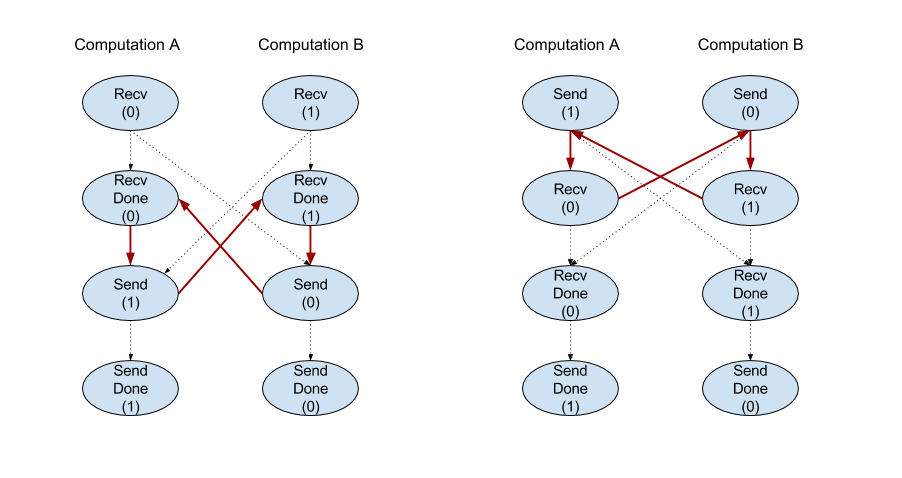

## Slice

See also [`ComputationBuilder::Slice`](https://www.github.com/tensorflow/tensorflow/blob/r1.8/tensorflow/compiler/xla/client/computation_builder.h).

Slicing extracts a sub-array from the input array. The sub-array is of the same rank as the input and contains the values inside a bounding box within the input array where the dimensions and indices of the bounding box are given as arguments to the slice operation.

**`Slice(operand, start_indices, limit_indices)`**

[output not shown]

1-dimensional example:

```
let a = {0.0, 1.0, 2.0, 3.0, 4.0}
Slice(a, {2}, {4}) produces:
  {2.0, 3.0}
```

2-dimensional example:

```
let b =
 { {0.0,  1.0,  2.0},
   {3.0,  4.0,  5.0},
   {6.0,  7.0,  8.0},
   {9.0, 10.0, 11.0} }

Slice(b, {2, 1}, {4, 3}) produces:
  { { 7.0,  8.0},
    {10.0, 11.0} }
```

## Sort

See also [`ComputationBuilder::Sort`](https://www.github.com/tensorflow/tensorflow/blob/r1.8/tensorflow/compiler/xla/client/computation_builder.h).

Sorts the elements in the operand.

**`Sort(operand)`**

| Arguments | Type | Semantics |
| --- | --- | --- |
| `operand` | `ComputationDataHandle` | The operand to sort |

## Transpose

See also the [`tf.reshape`](https://www.tensorflow.org/api_docs/python/tf/reshape) operation.

**`Transpose(operand)`**

| Arguments | Type | Semantics |
| --- | --- | --- |
| `operand` | `ComputationDataHandle` | The operand to transpose. |
| `permutation` | `ArraySlice<int64>` | How to permute the dimensions. |

Permutes the operand dimensions with the given permutation, so `∀ i . 0 ≤ i < rank ⇒ input_dimensions[permutation[i]] = output_dimensions[i]`.

This is the same as Reshape(operand, permutation, Permute(permutation, operand.shape.dimensions)).

## Tuple

See also [`ComputationBuilder::Tuple`](https://www.github.com/tensorflow/tensorflow/blob/r1.8/tensorflow/compiler/xla/client/computation_builder.h).

A tuple containing a variable number of data handles, each of which has its own shape.

This is analogous to `std::tuple` in C++. Conceptually:

```
let v: f32[10] = f32[10]{0, 1, 2, 3, 4, 5, 6, 7, 8, 9};
let s: s32 = 5;
let t: (f32[10], s32) = tuple(v, s);
```

Tuples can be deconstructed (accessed) via the `GetTupleElement` operation.

## While

See also [`ComputationBuilder::While`](https://www.github.com/tensorflow/tensorflow/blob/r1.8/tensorflow/compiler/xla/client/computation_builder.h).

**`While(condition, body, init)`**

| Arguments | Type | Semantics |
| --- | --- | --- |
| `condition` | `Computation` | Computation of type `T -> PRED` which defines the termination condition of the loop. |
| `body` | `Computation` | Computation of type `T -> T` which defines the body of the loop. |
| `init` | `T` | Initial value for the parameter of `condition` and `body`. |

Sequentially executes the `body` until the `condition` fails. This is similar to a typical while loop in many other languages except for the differences and restrictions listed below.

- A `While` node returns a value of type `T`, which is the result from the last execution of the `body`.
- The shape of the type `T` is statically determined and must be the same across all iterations.
- `While` nodes are not allowed to be nested. (This restriction may be lifted in the future on some targets.)

The T parameters of the computations are initialized with the `init` value in the first iteration and are automatically updated to the new result from `body` in each subsequent iteration.

One main use case of the `While` node is to implement the repeated execution of training in neural networks. Simplified pseudocode is shown below with a graph that represents the computation. The code can be found in [`while_test.cc`](https://www.github.com/tensorflow/tensorflow/blob/r1.8/tensorflow/compiler/xla/tests/while_test.cc). The type `T` in this example is a `Tuple` consisting of an `int32` for the iteration count and a `vector[10]` for the accumulator. For 1000 iterations, the loop keeps adding a constant vector to the accumulator.

```
// Pseudocode for the computation.
init = {0, zero_vector[10]} // Tuple of int32 and float[10].
result = init;
while (result(0) < 1000) {
  iteration = result(0) + 1;
  new_vector = result(1) + constant_vector[10];
  result = {iteration, new_vector};
}
```

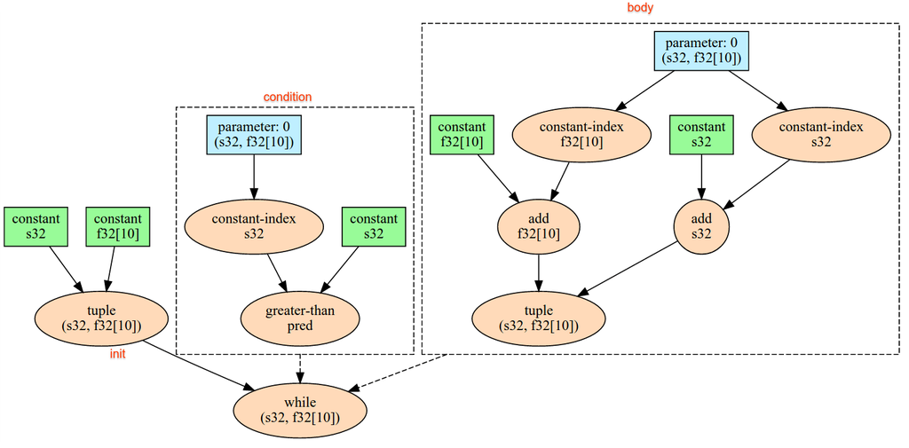